# Risk Factor Analysis

## Outcome Variable

**Outcome Variable:** wast_rec90d

## Predictor Variables

**Intervention Variable:** birthwt

**Adjustment Set:**

- arm
- sex
- W_mage
- meducyrs
- feducyrs
- hhwealth_quart
- vagbrth
- W_nrooms
- brthmon
- W_parity
- impfloor
- impsan
- safeh20
- delta_W_mage
- delta_meducyrs
- delta_feducyrs
- delta_hhwealth_quart
- delta_vagbrth
- delta_W_nrooms
- delta_brthmon
- delta_W_parity
- delta_impfloor
- delta_impsan
- delta_safeh20

## Stratifying Variables

The analysis was stratified on these variable(s):

- agecat
- studyid
- country

## Data Summary

| agecat | studyid | country | birthwt | wast_rec90d | n_cell | n |
| --- | --- | --- | --- | --- | --- | --- |
| 0-24 months | ki0047075b-MAL-ED | BANGLADESH | Normal or high birthweight | 0 | 31 | 119 |
| 0-24 months | ki0047075b-MAL-ED | BANGLADESH | Normal or high birthweight | 1 | 46 | 119 |
| 0-24 months | ki0047075b-MAL-ED | BANGLADESH | Low birth weight | 0 | 13 | 119 |
| 0-24 months | ki0047075b-MAL-ED | BANGLADESH | Low birth weight | 1 | 29 | 119 |
| 0-24 months | ki0047075b-MAL-ED | BRAZIL | Normal or high birthweight | 0 | 5 | 23 |
| 0-24 months | ki0047075b-MAL-ED | BRAZIL | Normal or high birthweight | 1 | 16 | 23 |
| 0-24 months | ki0047075b-MAL-ED | BRAZIL | Low birth weight | 0 | 1 | 23 |
| 0-24 months | ki0047075b-MAL-ED | BRAZIL | Low birth weight | 1 | 1 | 23 |
| 0-24 months | ki0047075b-MAL-ED | INDIA | Normal or high birthweight | 0 | 44 | 166 |
| 0-24 months | ki0047075b-MAL-ED | INDIA | Normal or high birthweight | 1 | 76 | 166 |
| 0-24 months | ki0047075b-MAL-ED | INDIA | Low birth weight | 0 | 21 | 166 |
| 0-24 months | ki0047075b-MAL-ED | INDIA | Low birth weight | 1 | 25 | 166 |
| 0-24 months | ki0047075b-MAL-ED | NEPAL | Normal or high birthweight | 0 | 12 | 85 |
| 0-24 months | ki0047075b-MAL-ED | NEPAL | Normal or high birthweight | 1 | 55 | 85 |
| 0-24 months | ki0047075b-MAL-ED | NEPAL | Low birth weight | 0 | 4 | 85 |
| 0-24 months | ki0047075b-MAL-ED | NEPAL | Low birth weight | 1 | 14 | 85 |
| 0-24 months | ki0047075b-MAL-ED | PERU | Normal or high birthweight | 0 | 3 | 34 |
| 0-24 months | ki0047075b-MAL-ED | PERU | Normal or high birthweight | 1 | 22 | 34 |
| 0-24 months | ki0047075b-MAL-ED | PERU | Low birth weight | 0 | 3 | 34 |
| 0-24 months | ki0047075b-MAL-ED | PERU | Low birth weight | 1 | 6 | 34 |
| 0-24 months | ki0047075b-MAL-ED | SOUTH AFRICA | Normal or high birthweight | 0 | 16 | 83 |
| 0-24 months | ki0047075b-MAL-ED | SOUTH AFRICA | Normal or high birthweight | 1 | 52 | 83 |
| 0-24 months | ki0047075b-MAL-ED | SOUTH AFRICA | Low birth weight | 0 | 1 | 83 |
| 0-24 months | ki0047075b-MAL-ED | SOUTH AFRICA | Low birth weight | 1 | 14 | 83 |
| 0-24 months | ki0047075b-MAL-ED | TANZANIA, UNITED REPUBLIC OF | Normal or high birthweight | 0 | 3 | 24 |
| 0-24 months | ki0047075b-MAL-ED | TANZANIA, UNITED REPUBLIC OF | Normal or high birthweight | 1 | 19 | 24 |
| 0-24 months | ki0047075b-MAL-ED | TANZANIA, UNITED REPUBLIC OF | Low birth weight | 0 | 0 | 24 |
| 0-24 months | ki0047075b-MAL-ED | TANZANIA, UNITED REPUBLIC OF | Low birth weight | 1 | 2 | 24 |
| 0-24 months | ki1000108-CMC-V-BCS-2002 | INDIA | Normal or high birthweight | 0 | 97 | 326 |
| 0-24 months | ki1000108-CMC-V-BCS-2002 | INDIA | Normal or high birthweight | 1 | 175 | 326 |

[output cut: 298 more lines]

The following strata were considered:

- agecat: 0-24 months, studyid: ki0047075b-MAL-ED, country: BANGLADESH
- agecat: 0-24 months, studyid: ki0047075b-MAL-ED, country: BRAZIL
- agecat: 0-24 months, studyid: ki0047075b-MAL-ED, country: INDIA
- agecat: 0-24 months, studyid: ki0047075b-MAL-ED, country: NEPAL
- agecat: 0-24 months, studyid: ki0047075b-MAL-ED, country: PERU
- agecat: 0-24 months, studyid: ki0047075b-MAL-ED, country: SOUTH AFRICA
- agecat: 0-24 months, studyid: ki0047075b-MAL-ED, country: TANZANIA, UNITED REPUBLIC OF
- agecat: 0-24 months, studyid: ki1000108-CMC-V-BCS-2002, country: INDIA
- agecat: 0-24 months, studyid: ki1000108-IRC, country: INDIA
- agecat: 0-24 months, studyid: ki1000109-EE, country: PAKISTAN
- agecat: 0-24 months, studyid: ki1000109-ResPak, country: PAKISTAN
- agecat: 0-24 months, studyid: ki1000304b-SAS-CompFeed, country: INDIA
- agecat: 0-24 months, studyid: ki1017093-NIH-Birth, country: BANGLADESH
- agecat: 0-24 months, studyid: ki1017093b-PROVIDE, country: BANGLADESH
- agecat: 0-24 months, studyid: ki1017093c-NIH-Crypto, country: BANGLADESH
- agecat: 0-24 months, studyid: ki1066203-TanzaniaChild2, country: TANZANIA, UNITED REPUBLIC OF
- agecat: 0-24 months, studyid: ki1101329-Keneba, country: GAMBIA
- agecat: 0-24 months, studyid: ki1114097-CMIN, country: BANGLADESH
- agecat: 0-24 months, studyid: ki1114097-CMIN, country: BRAZIL
- agecat: 0-24 months, studyid: ki1114097-CMIN, country: GUINEA-BISSAU
- agecat: 0-24 months, studyid: ki1114097-CMIN, country: PERU
- agecat: 0-24 months, studyid: ki1119695-PROBIT, country: BELARUS
- agecat: 0-24 months, studyid: ki1126311-ZVITAMBO, country: ZIMBABWE
- agecat: 0-24 months, studyid: ki1135781-COHORTS, country: GUATEMALA
- agecat: 0-24 months, studyid: ki1135781-COHORTS, country: INDIA
- agecat: 0-24 months, studyid: ki1135781-COHORTS, country: PHILIPPINES
- agecat: 0-24 months, studyid: kiGH5241-JiVitA-3, country: BANGLADESH
- agecat: 0-24 months, studyid: kiGH5241-JiVitA-4, country: BANGLADESH
- agecat: 0-6 months, studyid: ki0047075b-MAL-ED, country: BANGLADESH
- agecat: 0-6 months, studyid: ki0047075b-MAL-ED, country: BRAZIL
- agecat: 0-6 months, studyid: ki0047075b-MAL-ED, country: INDIA
- agecat: 0-6 months, studyid: ki0047075b-MAL-ED, country: NEPAL
- agecat: 0-6 months, studyid: ki0047075b-MAL-ED, country: PERU
- agecat: 0-6 months, studyid: ki0047075b-MAL-ED, country: SOUTH AFRICA
- agecat: 0-6 months, studyid: ki0047075b-MAL-ED, country: TANZANIA, UNITED REPUBLIC OF
- agecat: 0-6 months, studyid: ki1000108-CMC-V-BCS-2002, country: INDIA
- agecat: 0-6 months, studyid: ki1000108-IRC, country: INDIA
- agecat: 0-6 months, studyid: ki1000109-EE, country: PAKISTAN
- agecat: 0-6 months, studyid: ki1000109-ResPak, country: PAKISTAN
- agecat: 0-6 months, studyid: ki1000304b-SAS-CompFeed, country: INDIA
- agecat: 0-6 months, studyid: ki1017093-NIH-Birth, country: BANGLADESH
- agecat: 0-6 months, studyid: ki1017093b-PROVIDE, country: BANGLADESH
- agecat: 0-6 months, studyid: ki1017093c-NIH-Crypto, country: BANGLADESH
- agecat: 0-6 months, studyid: ki1066203-TanzaniaChild2, country: TANZANIA, UNITED REPUBLIC OF
- agecat: 0-6 months, studyid: ki1101329-Keneba, country: GAMBIA
- agecat: 0-6 months, studyid: ki1114097-CMIN, country: BANGLADESH
- agecat: 0-6 months, studyid: ki1114097-CMIN, country: BRAZIL
- agecat: 0-6 months, studyid: ki1114097-CMIN, country: GUINEA-BISSAU
- agecat: 0-6 months, studyid: ki1114097-CMIN, country: PERU
- agecat: 0-6 months, studyid: ki1119695-PROBIT, country: BELARUS
- agecat: 0-6 months, studyid: ki1126311-ZVITAMBO, country: ZIMBABWE
- agecat: 0-6 months, studyid: ki1135781-COHORTS, country: GUATEMALA
- agecat: 0-6 months, studyid: ki1135781-COHORTS, country: INDIA
- agecat: 0-6 months, studyid: ki1135781-COHORTS, country: PHILIPPINES
- agecat: 0-6 months, studyid: kiGH5241-JiVitA-3, country: BANGLADESH
- agecat: 0-6 months, studyid: kiGH5241-JiVitA-4, country: BANGLADESH
- agecat: 6-24 months, studyid: ki0047075b-MAL-ED, country: BANGLADESH
- agecat: 6-24 months, studyid: ki0047075b-MAL-ED, country: BRAZIL
- agecat: 6-24 months, studyid: ki0047075b-MAL-ED, country: INDIA
- agecat: 6-24 months, studyid: ki0047075b-MAL-ED, country: NEPAL
- agecat: 6-24 months, studyid: ki0047075b-MAL-ED, country: PERU
- agecat: 6-24 months, studyid: ki0047075b-MAL-ED, country: SOUTH AFRICA
- agecat: 6-24 months, studyid: ki0047075b-MAL-ED, country: TANZANIA, UNITED REPUBLIC OF
- agecat: 6-24 months, studyid: ki1000108-CMC-V-BCS-2002, country: INDIA
- agecat: 6-24 months, studyid: ki1000108-IRC, country: INDIA
- agecat: 6-24 months, studyid: ki1000109-EE, country: PAKISTAN
- agecat: 6-24 months, studyid: ki1000109-ResPak, country: PAKISTAN
- agecat: 6-24 months, studyid: ki1000304b-SAS-CompFeed, country: INDIA
- agecat: 6-24 months, studyid: ki1017093-NIH-Birth, country: BANGLADESH
- agecat: 6-24 months, studyid: ki1017093b-PROVIDE, country: BANGLADESH
- agecat: 6-24 months, studyid: ki1017093c-NIH-Crypto, country: BANGLADESH
- agecat: 6-24 months, studyid: ki1066203-TanzaniaChild2, country: TANZANIA, UNITED REPUBLIC OF
- agecat: 6-24 months, studyid: ki1101329-Keneba, country: GAMBIA
- agecat: 6-24 months, studyid: ki1114097-CMIN, country: BRAZIL
- agecat: 6-24 months, studyid: ki1114097-CMIN, country: PERU
- agecat: 6-24 months, studyid: ki1119695-PROBIT, country: BELARUS
- agecat: 6-24 months, studyid: ki1126311-ZVITAMBO, country: ZIMBABWE
- agecat: 6-24 months, studyid: ki1135781-COHORTS, country: GUATEMALA
- agecat: 6-24 months, studyid: ki1135781-COHORTS, country: INDIA
- agecat: 6-24 months, studyid: ki1135781-COHORTS, country: PHILIPPINES
- agecat: 6-24 months, studyid: kiGH5241-JiVitA-3, country: BANGLADESH
- agecat: 6-24 months, studyid: kiGH5241-JiVitA-4, country: BANGLADESH

### Dropped Strata

Some strata were dropped due to rare outcomes:

- agecat: 0-24 months, studyid: ki0047075b-MAL-ED, country: BRAZIL
- agecat: 0-24 months, studyid: ki0047075b-MAL-ED, country: NEPAL
- agecat: 0-24 months, studyid: ki0047075b-MAL-ED, country: PERU
- agecat: 0-24 months, studyid: ki0047075b-MAL-ED, country: SOUTH AFRICA
- agecat: 0-24 months, studyid: ki0047075b-MAL-ED, country: TANZANIA, UNITED REPUBLIC OF
- agecat: 0-24 months, studyid: ki1000109-ResPak, country: PAKISTAN
- agecat: 0-24 months, studyid: ki1114097-CMIN, country: BANGLADESH
- agecat: 0-24 months, studyid: ki1114097-CMIN, country: BRAZIL
- agecat: 0-24 months, studyid: ki1114097-CMIN, country: GUINEA-BISSAU
- agecat: 0-24 months, studyid: ki1114097-CMIN, country: PERU
- agecat: 0-24 months, studyid: ki1119695-PROBIT, country: BELARUS
- agecat: 0-6 months, studyid: ki0047075b-MAL-ED, country: BANGLADESH
- agecat: 0-6 months, studyid: ki0047075b-MAL-ED, country: BRAZIL
- agecat: 0-6 months, studyid: ki0047075b-MAL-ED, country: NEPAL
- agecat: 0-6 months, studyid: ki0047075b-MAL-ED, country: PERU
- agecat: 0-6 months, studyid: ki0047075b-MAL-ED, country: SOUTH AFRICA
- agecat: 0-6 months, studyid: ki0047075b-MAL-ED, country: TANZANIA, UNITED REPUBLIC OF
- agecat: 0-6 months, studyid: ki1000109-ResPak, country: PAKISTAN
- agecat: 0-6 months, studyid: ki1114097-CMIN, country: BANGLADESH
- agecat: 0-6 months, studyid: ki1114097-CMIN, country: BRAZIL
- agecat: 0-6 months, studyid: ki1114097-CMIN, country: GUINEA-BISSAU
- agecat: 0-6 months, studyid: ki1114097-CMIN, country: PERU
- agecat: 0-6 months, studyid: ki1119695-PROBIT, country: BELARUS
- agecat: 6-24 months, studyid: ki0047075b-MAL-ED, country: BRAZIL
- agecat: 6-24 months, studyid: ki0047075b-MAL-ED, country: NEPAL
- agecat: 6-24 months, studyid: ki0047075b-MAL-ED, country: PERU
- agecat: 6-24 months, studyid: ki0047075b-MAL-ED, country: SOUTH AFRICA
- agecat: 6-24 months, studyid: ki0047075b-MAL-ED, country: TANZANIA, UNITED REPUBLIC OF
- agecat: 6-24 months, studyid: ki1000109-ResPak, country: PAKISTAN
- agecat: 6-24 months, studyid: ki1017093c-NIH-Crypto, country: BANGLADESH
- agecat: 6-24 months, studyid: ki1114097-CMIN, country: BRAZIL
- agecat: 6-24 months, studyid: ki1114097-CMIN, country: PERU
- agecat: 6-24 months, studyid: ki1119695-PROBIT, country: BELARUS
- agecat: 6-24 months, studyid: ki1135781-COHORTS, country: GUATEMALA
- agecat: 6-24 months, studyid: ki1135781-COHORTS, country: INDIA
- agecat: 6-24 months, studyid: kiGH5241-JiVitA-3, country: BANGLADESH

## Methods Detail

We’re interested in the causal parameters $E[Y_a]$ for all values of $a \in \mathcal{A}$. These parameters represent the mean outcome if, possibly contrary to fact, we intervened to set all units to have $A=a$. Under the randomization and positivity assumptions, these are identified by the statistical parameters $\psi_a=E_W[E_{Y|A,W}(Y|A=a,W)]$. In addition, we’re interested in the mean of $Y$, $E[Y]$ under no intervention (the observed mean). We will estimate these parameters by using SuperLearner to fit the relevant likelihood factors – $E_{Y|A,W}(Y|A=a,W)$ and $p(A=a|W)$, and then updating our likelihood fit using a joint TMLE.

For unadjusted analyses ($W=\{\}$), initial likelihoods were estimated using Lrnr_glm to estimate the simple $E(Y|A)$ and Lrnr_mean to estimate $p(A)$. For adjusted analyses, a small library containing Lrnr_glmnet, Lrnr_xgboost, and Lrnr_mean was used.

Having estimated these parameters, we will then use the delta method to estimate relative risks and attributable risks relative to a prespecified baseline level of $A$.

# Results Detail

## Results Plots

[figure not shown]

[figure not shown]

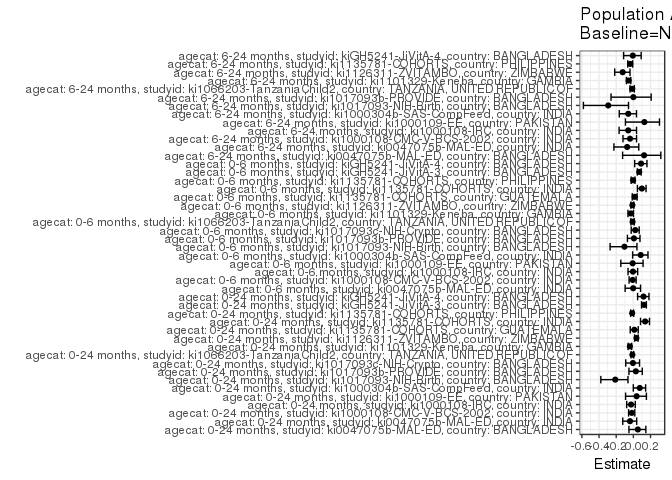

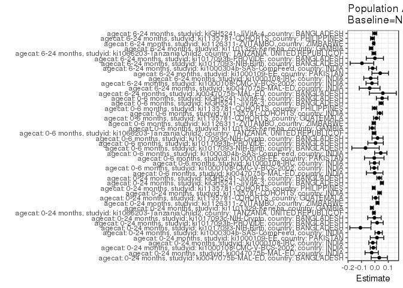

## Results Table

### Parameter: TSM

| agecat | studyid | country | intervention_level | baseline_level | estimate | ci_lower | ci_upper |
| --- | --- | --- | --- | --- | --- | --- | --- |
| 0-24 months | ki0047075b-MAL-ED | BANGLADESH | Normal or high birthweight | NA | 0.5974026 | 0.4767305 | 0.7180747 |
| 0-24 months | ki0047075b-MAL-ED | BANGLADESH | Low birth weight | NA | 0.6904762 | 0.5765104 | 0.8044420 |
| 0-24 months | ki0047075b-MAL-ED | INDIA | Normal or high birthweight | NA | 0.6323335 | 0.5340913 | 0.7305758 |
| 0-24 months | ki0047075b-MAL-ED | INDIA | Low birth weight | NA | 0.5462604 | 0.3990300 | 0.6934909 |
| 0-24 months | ki1000108-CMC-V-BCS-2002 | INDIA | Normal or high birthweight | NA | 0.6437797 | 0.5816403 | 0.7059190 |
| 0-24 months | ki1000108-CMC-V-BCS-2002 | INDIA | Low birth weight | NA | 0.5708580 | 0.4531409 | 0.6885752 |
| 0-24 months | ki1000108-IRC | INDIA | Normal or high birthweight | NA | 0.6045616 | 0.5438164 | 0.6653067 |
| 0-24 months | ki1000108-IRC | INDIA | Low birth weight | NA | 0.5694859 | 0.4791952 | 0.6597766 |
| 0-24 months | ki1000109-EE | PAKISTAN | Normal or high birthweight | NA | 0.4003943 | 0.3172758 | 0.4835128 |
| 0-24 months | ki1000109-EE | PAKISTAN | Low birth weight | NA | 0.4499422 | 0.3608018 | 0.5390826 |
| 0-24 months | ki1000304b-SAS-CompFeed | INDIA | Normal or high birthweight | NA | 0.3539207 | 0.3081909 | 0.3996504 |
| 0-24 months | ki1000304b-SAS-CompFeed | INDIA | Low birth weight | NA | 0.3988290 | 0.3475726 | 0.4500854 |
| 0-24 months | ki1017093-NIH-Birth | BANGLADESH | Normal or high birthweight | NA | 0.6195976 | 0.5071819 | 0.7320134 |
| 0-24 months | ki1017093-NIH-Birth | BANGLADESH | Low birth weight | NA | 0.5422840 | 0.4422323 | 0.6423358 |
| 0-24 months | ki1017093b-PROVIDE | BANGLADESH | Normal or high birthweight | NA | 0.5660459 | 0.4928212 | 0.6392706 |
| 0-24 months | ki1017093b-PROVIDE | BANGLADESH | Low birth weight | NA | 0.6206819 | 0.5491651 | 0.6921988 |
| 0-24 months | ki1017093c-NIH-Crypto | BANGLADESH | Normal or high birthweight | NA | 0.6270294 | 0.5461109 | 0.7079479 |
| 0-24 months | ki1017093c-NIH-Crypto | BANGLADESH | Low birth weight | NA | 0.6202472 | 0.5511773 | 0.6893172 |
| 0-24 months | ki1066203-TanzaniaChild2 | TANZANIA, UNITED REPUBLIC OF | Normal or high birthweight | NA | 0.6330884 | 0.5941332 | 0.6720436 |
| 0-24 months | ki1066203-TanzaniaChild2 | TANZANIA, UNITED REPUBLIC OF | Low birth weight | NA | 0.6834223 | 0.5410484 | 0.8257962 |
| 0-24 months | ki1101329-Keneba | GAMBIA | Normal or high birthweight | NA | 0.5744802 | 0.5423174 | 0.6066430 |
| 0-24 months | ki1101329-Keneba | GAMBIA | Low birth weight | NA | 0.2858589 | 0.2166061 | 0.3551116 |
| 0-24 months | ki1126311-ZVITAMBO | ZIMBABWE | Normal or high birthweight | NA | 0.5256066 | 0.5056223 | 0.5455909 |
| 0-24 months | ki1126311-ZVITAMBO | ZIMBABWE | Low birth weight | NA | 0.5964505 | 0.5691167 | 0.6237843 |
| 0-24 months | ki1135781-COHORTS | GUATEMALA | Normal or high birthweight | NA | 0.5098159 | 0.4495452 | 0.5700865 |
| 0-24 months | ki1135781-COHORTS | GUATEMALA | Low birth weight | NA | 0.5624536 | 0.4244871 | 0.7004200 |
| 0-24 months | ki1135781-COHORTS | INDIA | Normal or high birthweight | NA | 0.2207890 | 0.2000296 | 0.2415485 |
| 0-24 months | ki1135781-COHORTS | INDIA | Low birth weight | NA | 0.3220418 | 0.2938278 | 0.3502559 |
| 0-24 months | ki1135781-COHORTS | PHILIPPINES | Normal or high birthweight | NA | 0.6154682 | 0.5877893 | 0.6431470 |
| 0-24 months | ki1135781-COHORTS | PHILIPPINES | Low birth weight | NA | 0.5998888 | 0.5530344 | 0.6467432 |

[output cut: 62 more lines]

### Parameter: E(Y)

| agecat | studyid | country | intervention_level | baseline_level | estimate | ci_lower | ci_upper |
| --- | --- | --- | --- | --- | --- | --- | --- |
| 0-24 months | ki0047075b-MAL-ED | BANGLADESH | NA | NA | 0.6302521 | 0.5419905 | 0.7185137 |
| 0-24 months | ki0047075b-MAL-ED | INDIA | NA | NA | 0.6084337 | 0.5263180 | 0.6905495 |
| 0-24 months | ki1000108-CMC-V-BCS-2002 | INDIA | NA | NA | 0.6319018 | 0.5759256 | 0.6878781 |
| 0-24 months | ki1000108-IRC | INDIA | NA | NA | 0.5888325 | 0.5365454 | 0.6411196 |
| 0-24 months | ki1000109-EE | PAKISTAN | NA | NA | 0.4163424 | 0.3511349 | 0.4815500 |
| 0-24 months | ki1000304b-SAS-CompFeed | INDIA | NA | NA | 0.3822441 | 0.3470621 | 0.4174262 |
| 0-24 months | ki1017093-NIH-Birth | BANGLADESH | NA | NA | 0.5117647 | 0.4302715 | 0.5932579 |
| 0-24 months | ki1017093b-PROVIDE | BANGLADESH | NA | NA | 0.5830619 | 0.5262762 | 0.6398476 |
| 0-24 months | ki1017093c-NIH-Crypto | BANGLADESH | NA | NA | 0.6237942 | 0.5698223 | 0.6777662 |
| 0-24 months | ki1066203-TanzaniaChild2 | TANZANIA, UNITED REPUBLIC OF | NA | NA | 0.6258890 | 0.5879514 | 0.6638267 |
| 0-24 months | ki1101329-Keneba | GAMBIA | NA | NA | 0.5519802 | 0.5212828 | 0.5826776 |
| 0-24 months | ki1126311-ZVITAMBO | ZIMBABWE | NA | NA | 0.5451233 | 0.5286432 | 0.5616034 |
| 0-24 months | ki1135781-COHORTS | GUATEMALA | NA | NA | 0.5156250 | 0.4594779 | 0.5717721 |
| 0-24 months | ki1135781-COHORTS | INDIA | NA | NA | 0.2559618 | 0.2388022 | 0.2731215 |
| 0-24 months | ki1135781-COHORTS | PHILIPPINES | NA | NA | 0.6069712 | 0.5823178 | 0.6316245 |
| 0-24 months | kiGH5241-JiVitA-3 | BANGLADESH | NA | NA | 0.4229675 | 0.4118348 | 0.4341003 |
| 0-24 months | kiGH5241-JiVitA-4 | BANGLADESH | NA | NA | 0.2782438 | 0.2567862 | 0.2997015 |
| 0-6 months | ki0047075b-MAL-ED | INDIA | NA | NA | 0.6883117 | 0.5823564 | 0.7942670 |
| 0-6 months | ki1000108-CMC-V-BCS-2002 | INDIA | NA | NA | 0.6748768 | 0.6092233 | 0.7405304 |
| 0-6 months | ki1000108-IRC | INDIA | NA | NA | 0.6359833 | 0.5734338 | 0.6985327 |
| 0-6 months | ki1000109-EE | PAKISTAN | NA | NA | 0.5648148 | 0.4692893 | 0.6603404 |
| 0-6 months | ki1000304b-SAS-CompFeed | INDIA | NA | NA | 0.5147059 | 0.4610948 | 0.5683169 |
| 0-6 months | ki1017093-NIH-Birth | BANGLADESH | NA | NA | 0.6703297 | 0.5732092 | 0.7674502 |
| 0-6 months | ki1017093b-PROVIDE | BANGLADESH | NA | NA | 0.7880435 | 0.7295878 | 0.8464992 |
| 0-6 months | ki1017093c-NIH-Crypto | BANGLADESH | NA | NA | 0.8939394 | 0.8505280 | 0.9373508 |
| 0-6 months | ki1066203-TanzaniaChild2 | TANZANIA, UNITED REPUBLIC OF | NA | NA | 0.7014925 | 0.6517566 | 0.7512285 |
| 0-6 months | ki1101329-Keneba | GAMBIA | NA | NA | 0.6616766 | 0.6110579 | 0.7122953 |
| 0-6 months | ki1126311-ZVITAMBO | ZIMBABWE | NA | NA | 0.7439364 | 0.7268897 | 0.7609830 |
| 0-6 months | ki1135781-COHORTS | GUATEMALA | NA | NA | 0.7619048 | 0.7043195 | 0.8194900 |
| 0-6 months | ki1135781-COHORTS | INDIA | NA | NA | 0.3750728 | 0.3521661 | 0.3979795 |
| 0-6 months | ki1135781-COHORTS | PHILIPPINES | NA | NA | 0.7372654 | 0.7055895 | 0.7689413 |
| 0-6 months | kiGH5241-JiVitA-3 | BANGLADESH | NA | NA | 0.6760414 | 0.6627031 | 0.6893798 |
| 0-6 months | kiGH5241-JiVitA-4 | BANGLADESH | NA | NA | 0.6058824 | 0.5634305 | 0.6483342 |
| 6-24 months | ki0047075b-MAL-ED | BANGLADESH | NA | NA | 0.4745763 | 0.3430726 | 0.6060800 |
| 6-24 months | ki0047075b-MAL-ED | INDIA | NA | NA | 0.5393258 | 0.4214529 | 0.6571988 |
| 6-24 months | ki1000108-CMC-V-BCS-2002 | INDIA | NA | NA | 0.5609756 | 0.4682842 | 0.6536670 |
| 6-24 months | ki1000108-IRC | INDIA | NA | NA | 0.5161290 | 0.4322562 | 0.6000019 |
| 6-24 months | ki1000109-EE | PAKISTAN | NA | NA | 0.3087248 | 0.2336906 | 0.3837591 |
| 6-24 months | ki1000304b-SAS-CompFeed | INDIA | NA | NA | 0.2866242 | 0.2446853 | 0.3285631 |
| 6-24 months | ki1017093-NIH-Birth | BANGLADESH | NA | NA | 0.3291139 | 0.2187678 | 0.4394600 |
| 6-24 months | ki1017093b-PROVIDE | BANGLADESH | NA | NA | 0.2764228 | 0.1950773 | 0.3577682 |
| 6-24 months | ki1066203-TanzaniaChild2 | TANZANIA, UNITED REPUBLIC OF | NA | NA | 0.5570652 | 0.5044805 | 0.6096499 |
| 6-24 months | ki1101329-Keneba | GAMBIA | NA | NA | 0.5102506 | 0.4747348 | 0.5457664 |
| 6-24 months | ki1126311-ZVITAMBO | ZIMBABWE | NA | NA | 0.0702754 | 0.0549673 | 0.0855835 |
| 6-24 months | ki1135781-COHORTS | PHILIPPINES | NA | NA | 0.5010893 | 0.4669869 | 0.5351918 |
| 6-24 months | kiGH5241-JiVitA-4 | BANGLADESH | NA | NA | 0.1474961 | 0.1282628 | 0.1667294 |

### Parameter: RR

| agecat | studyid | country | intervention_level | baseline_level | estimate | ci_lower | ci_upper |
| --- | --- | --- | --- | --- | --- | --- | --- |
| 0-24 months | ki0047075b-MAL-ED | BANGLADESH | Normal or high birthweight | Normal or high birthweight | 1.0000000 | 1.0000000 | 1.0000000 |
| 0-24 months | ki0047075b-MAL-ED | BANGLADESH | Low birth weight | Normal or high birthweight | 1.1557971 | 0.8898058 | 1.5013017 |
| 0-24 months | ki0047075b-MAL-ED | INDIA | Normal or high birthweight | Normal or high birthweight | 1.0000000 | 1.0000000 | 1.0000000 |
| 0-24 months | ki0047075b-MAL-ED | INDIA | Low birth weight | Normal or high birthweight | 0.8638802 | 0.6332607 | 1.1784863 |
| 0-24 months | ki1000108-CMC-V-BCS-2002 | INDIA | Normal or high birthweight | Normal or high birthweight | 1.0000000 | 1.0000000 | 1.0000000 |
| 0-24 months | ki1000108-CMC-V-BCS-2002 | INDIA | Low birth weight | Normal or high birthweight | 0.8867289 | 0.7066624 | 1.1126786 |
| 0-24 months | ki1000108-IRC | INDIA | Normal or high birthweight | Normal or high birthweight | 1.0000000 | 1.0000000 | 1.0000000 |
| 0-24 months | ki1000108-IRC | INDIA | Low birth weight | Normal or high birthweight | 0.9419817 | 0.7808217 | 1.1364048 |
| 0-24 months | ki1000109-EE | PAKISTAN | Normal or high birthweight | Normal or high birthweight | 1.0000000 | 1.0000000 | 1.0000000 |
| 0-24 months | ki1000109-EE | PAKISTAN | Low birth weight | Normal or high birthweight | 1.1237478 | 0.8471746 | 1.4906127 |
| 0-24 months | ki1000304b-SAS-CompFeed | INDIA | Normal or high birthweight | Normal or high birthweight | 1.0000000 | 1.0000000 | 1.0000000 |
| 0-24 months | ki1000304b-SAS-CompFeed | INDIA | Low birth weight | Normal or high birthweight | 1.1268882 | 0.9398351 | 1.3511699 |
| 0-24 months | ki1017093-NIH-Birth | BANGLADESH | Normal or high birthweight | Normal or high birthweight | 1.0000000 | 1.0000000 | 1.0000000 |
| 0-24 months | ki1017093-NIH-Birth | BANGLADESH | Low birth weight | Normal or high birthweight | 0.8752197 | 0.6733555 | 1.1376005 |
| 0-24 months | ki1017093b-PROVIDE | BANGLADESH | Normal or high birthweight | Normal or high birthweight | 1.0000000 | 1.0000000 | 1.0000000 |
| 0-24 months | ki1017093b-PROVIDE | BANGLADESH | Low birth weight | Normal or high birthweight | 1.0965223 | 0.9276465 | 1.2961416 |
| 0-24 months | ki1017093c-NIH-Crypto | BANGLADESH | Normal or high birthweight | Normal or high birthweight | 1.0000000 | 1.0000000 | 1.0000000 |
| 0-24 months | ki1017093c-NIH-Crypto | BANGLADESH | Low birth weight | Normal or high birthweight | 0.9891837 | 0.8343740 | 1.1727167 |
| 0-24 months | ki1066203-TanzaniaChild2 | TANZANIA, UNITED REPUBLIC OF | Normal or high birthweight | Normal or high birthweight | 1.0000000 | 1.0000000 | 1.0000000 |
| 0-24 months | ki1066203-TanzaniaChild2 | TANZANIA, UNITED REPUBLIC OF | Low birth weight | Normal or high birthweight | 1.0795053 | 0.8687864 | 1.3413329 |
| 0-24 months | ki1101329-Keneba | GAMBIA | Normal or high birthweight | Normal or high birthweight | 1.0000000 | 1.0000000 | 1.0000000 |
| 0-24 months | ki1101329-Keneba | GAMBIA | Low birth weight | Normal or high birthweight | 0.4975957 | 0.3881006 | 0.6379828 |
| 0-24 months | ki1126311-ZVITAMBO | ZIMBABWE | Normal or high birthweight | Normal or high birthweight | 1.0000000 | 1.0000000 | 1.0000000 |
| 0-24 months | ki1126311-ZVITAMBO | ZIMBABWE | Low birth weight | Normal or high birthweight | 1.1347850 | 1.0693685 | 1.2042033 |
| 0-24 months | ki1135781-COHORTS | GUATEMALA | Normal or high birthweight | Normal or high birthweight | 1.0000000 | 1.0000000 | 1.0000000 |
| 0-24 months | ki1135781-COHORTS | GUATEMALA | Low birth weight | Normal or high birthweight | 1.1032485 | 0.8402413 | 1.4485804 |
| 0-24 months | ki1135781-COHORTS | INDIA | Normal or high birthweight | Normal or high birthweight | 1.0000000 | 1.0000000 | 1.0000000 |
| 0-24 months | ki1135781-COHORTS | INDIA | Low birth weight | Normal or high birthweight | 1.4585951 | 1.2833618 | 1.6577551 |
| 0-24 months | ki1135781-COHORTS | PHILIPPINES | Normal or high birthweight | Normal or high birthweight | 1.0000000 | 1.0000000 | 1.0000000 |
| 0-24 months | ki1135781-COHORTS | PHILIPPINES | Low birth weight | Normal or high birthweight | 0.9746869 | 0.8908575 | 1.0664047 |

[output cut: 62 more lines]

### Parameter: PAR

| agecat | studyid | country | intervention_level | baseline_level | estimate | ci_lower | ci_upper |
| --- | --- | --- | --- | --- | --- | --- | --- |
| 0-24 months | ki0047075b-MAL-ED | BANGLADESH | Normal or high birthweight | NA | 0.0328495 | -0.0276324 | 0.0933314 |
| 0-24 months | ki0047075b-MAL-ED | INDIA | Normal or high birthweight | NA | -0.0238998 | -0.0733487 | 0.0255491 |
| 0-24 months | ki1000108-CMC-V-BCS-2002 | INDIA | Normal or high birthweight | NA | -0.0118778 | -0.0347760 | 0.0110203 |
| 0-24 months | ki1000108-IRC | INDIA | Normal or high birthweight | NA | -0.0157291 | -0.0450892 | 0.0136310 |
| 0-24 months | ki1000109-EE | PAKISTAN | Normal or high birthweight | NA | 0.0159481 | -0.0343391 | 0.0662354 |
| 0-24 months | ki1000304b-SAS-CompFeed | INDIA | Normal or high birthweight | NA | 0.0283235 | 0.0011586 | 0.0554884 |
| 0-24 months | ki1017093-NIH-Birth | BANGLADESH | Normal or high birthweight | NA | -0.1078329 | -0.1864868 | -0.0291790 |
| 0-24 months | ki1017093b-PROVIDE | BANGLADESH | Normal or high birthweight | NA | 0.0170160 | -0.0281432 | 0.0621752 |
| 0-24 months | ki1017093c-NIH-Crypto | BANGLADESH | Normal or high birthweight | NA | -0.0032352 | -0.0533863 | 0.0469160 |
| 0-24 months | ki1066203-TanzaniaChild2 | TANZANIA, UNITED REPUBLIC OF | Normal or high birthweight | NA | -0.0071993 | -0.0169448 | 0.0025462 |
| 0-24 months | ki1101329-Keneba | GAMBIA | Normal or high birthweight | NA | -0.0225000 | -0.0339267 | -0.0110734 |
| 0-24 months | ki1126311-ZVITAMBO | ZIMBABWE | Normal or high birthweight | NA | 0.0195167 | 0.0086774 | 0.0303560 |
| 0-24 months | ki1135781-COHORTS | GUATEMALA | Normal or high birthweight | NA | 0.0058091 | -0.0181338 | 0.0297521 |
| 0-24 months | ki1135781-COHORTS | INDIA | Normal or high birthweight | NA | 0.0351728 | 0.0217750 | 0.0485706 |
| 0-24 months | ki1135781-COHORTS | PHILIPPINES | Normal or high birthweight | NA | -0.0084970 | -0.0192319 | 0.0022379 |
| 0-24 months | kiGH5241-JiVitA-3 | BANGLADESH | Normal or high birthweight | NA | 0.0524171 | 0.0405302 | 0.0643040 |
| 0-24 months | kiGH5241-JiVitA-4 | BANGLADESH | Normal or high birthweight | NA | 0.0328916 | 0.0146113 | 0.0511720 |
| 0-6 months | ki0047075b-MAL-ED | INDIA | Normal or high birthweight | NA | -0.0013435 | -0.0630803 | 0.0603933 |
| 0-6 months | ki1000108-CMC-V-BCS-2002 | INDIA | Normal or high birthweight | NA | -0.0053633 | -0.0329048 | 0.0221782 |
| 0-6 months | ki1000108-IRC | INDIA | Normal or high birthweight | NA | -0.0029056 | -0.0386202 | 0.0328090 |
| 0-6 months | ki1000109-EE | PAKISTAN | Normal or high birthweight | NA | -0.0046121 | -0.0775717 | 0.0683475 |
| 0-6 months | ki1000304b-SAS-CompFeed | INDIA | Normal or high birthweight | NA | 0.0439460 | -0.0018821 | 0.0897741 |
| 0-6 months | ki1017093-NIH-Birth | BANGLADESH | Normal or high birthweight | NA | -0.0695779 | -0.1718446 | 0.0326887 |
| 0-6 months | ki1017093b-PROVIDE | BANGLADESH | Normal or high birthweight | NA | 0.0053028 | -0.0523169 | 0.0629225 |
| 0-6 months | ki1017093c-NIH-Crypto | BANGLADESH | Normal or high birthweight | NA | 0.0201530 | -0.0212303 | 0.0615363 |
| 0-6 months | ki1066203-TanzaniaChild2 | TANZANIA, UNITED REPUBLIC OF | Normal or high birthweight | NA | -0.0064440 | -0.0201935 | 0.0073055 |
| 0-6 months | ki1101329-Keneba | GAMBIA | Normal or high birthweight | NA | -0.0198141 | -0.0410055 | 0.0013773 |
| 0-6 months | ki1126311-ZVITAMBO | ZIMBABWE | Normal or high birthweight | NA | -0.0083772 | -0.0211374 | 0.0043830 |
| 0-6 months | ki1135781-COHORTS | GUATEMALA | Normal or high birthweight | NA | 0.0119048 | -0.0096709 | 0.0334804 |
| 0-6 months | ki1135781-COHORTS | INDIA | Normal or high birthweight | NA | 0.0372019 | 0.0182632 | 0.0561406 |
| 0-6 months | ki1135781-COHORTS | PHILIPPINES | Normal or high birthweight | NA | -0.0022487 | -0.0187871 | 0.0142896 |
| 0-6 months | kiGH5241-JiVitA-3 | BANGLADESH | Normal or high birthweight | NA | 0.0464631 | 0.0315430 | 0.0613832 |
| 0-6 months | kiGH5241-JiVitA-4 | BANGLADESH | Normal or high birthweight | NA | 0.0543461 | 0.0111211 | 0.0975710 |
| 6-24 months | ki0047075b-MAL-ED | BANGLADESH | Normal or high birthweight | NA | 0.0594915 | -0.0407330 | 0.1597160 |
| 6-24 months | ki0047075b-MAL-ED | INDIA | Normal or high birthweight | NA | -0.0388561 | -0.1163380 | 0.0386258 |
| 6-24 months | ki1000108-CMC-V-BCS-2002 | INDIA | Normal or high birthweight | NA | -0.0218307 | -0.0659386 | 0.0222772 |
| 6-24 months | ki1000108-IRC | INDIA | Normal or high birthweight | NA | -0.0308798 | -0.0828402 | 0.0210806 |
| 6-24 months | ki1000109-EE | PAKISTAN | Normal or high birthweight | NA | 0.0396546 | -0.0220044 | 0.1013136 |
| 6-24 months | ki1000304b-SAS-CompFeed | INDIA | Normal or high birthweight | NA | -0.0169479 | -0.0456926 | 0.0117969 |
| 6-24 months | ki1017093-NIH-Birth | BANGLADESH | Normal or high birthweight | NA | -0.0964180 | -0.1841562 | -0.0086798 |
| 6-24 months | ki1017093b-PROVIDE | BANGLADESH | Normal or high birthweight | NA | 0.0001070 | -0.0639461 | 0.0641600 |
| 6-24 months | ki1066203-TanzaniaChild2 | TANZANIA, UNITED REPUBLIC OF | Normal or high birthweight | NA | -0.0074047 | -0.0214410 | 0.0066316 |
| 6-24 months | ki1101329-Keneba | GAMBIA | Normal or high birthweight | NA | -0.0280845 | -0.0408939 | -0.0152751 |
| 6-24 months | ki1126311-ZVITAMBO | ZIMBABWE | Normal or high birthweight | NA | -0.0087665 | -0.0152510 | -0.0022820 |
| 6-24 months | ki1135781-COHORTS | PHILIPPINES | Normal or high birthweight | NA | -0.0182503 | -0.0325911 | -0.0039095 |
| 6-24 months | kiGH5241-JiVitA-4 | BANGLADESH | Normal or high birthweight | NA | -0.0009116 | -0.0160120 | 0.0141889 |

### Parameter: PAF

| agecat | studyid | country | intervention_level | baseline_level | estimate | ci_lower | ci_upper |
| --- | --- | --- | --- | --- | --- | --- | --- |
| 0-24 months | ki0047075b-MAL-ED | BANGLADESH | Normal or high birthweight | NA | 0.0521212 | -0.0515027 | 0.1455332 |
| 0-24 months | ki0047075b-MAL-ED | INDIA | Normal or high birthweight | NA | -0.0392808 | -0.1236754 | 0.0387752 |
| 0-24 months | ki1000108-CMC-V-BCS-2002 | INDIA | Normal or high birthweight | NA | -0.0187970 | -0.0555885 | 0.0167122 |
| 0-24 months | ki1000108-IRC | INDIA | Normal or high birthweight | NA | -0.0267123 | -0.0777875 | 0.0219424 |
| 0-24 months | ki1000109-EE | PAKISTAN | Normal or high birthweight | NA | 0.0383054 | -0.0906918 | 0.1520459 |
| 0-24 months | ki1000304b-SAS-CompFeed | INDIA | Normal or high birthweight | NA | 0.0740979 | -0.0005621 | 0.1431869 |
| 0-24 months | ki1017093-NIH-Birth | BANGLADESH | Normal or high birthweight | NA | -0.2107080 | -0.3792502 | -0.0627614 |
| 0-24 months | ki1017093b-PROVIDE | BANGLADESH | Normal or high birthweight | NA | 0.0291839 | -0.0515565 | 0.1037248 |
| 0-24 months | ki1017093c-NIH-Crypto | BANGLADESH | Normal or high birthweight | NA | -0.0051863 | -0.0887866 | 0.0719950 |
| 0-24 months | ki1066203-TanzaniaChild2 | TANZANIA, UNITED REPUBLIC OF | Normal or high birthweight | NA | -0.0115026 | -0.0272255 | 0.0039797 |
| 0-24 months | ki1101329-Keneba | GAMBIA | Normal or high birthweight | NA | -0.0407624 | -0.0619227 | -0.0200237 |
| 0-24 months | ki1126311-ZVITAMBO | ZIMBABWE | Normal or high birthweight | NA | 0.0358024 | 0.0156500 | 0.0555422 |
| 0-24 months | ki1135781-COHORTS | GUATEMALA | Normal or high birthweight | NA | 0.0112662 | -0.0362486 | 0.0566023 |
| 0-24 months | ki1135781-COHORTS | INDIA | Normal or high birthweight | NA | 0.1374142 | 0.0835045 | 0.1881529 |
| 0-24 months | ki1135781-COHORTS | PHILIPPINES | Normal or high birthweight | NA | -0.0139990 | -0.0318023 | 0.0034971 |
| 0-24 months | kiGH5241-JiVitA-3 | BANGLADESH | Normal or high birthweight | NA | 0.1239270 | 0.0953138 | 0.1516351 |
| 0-24 months | kiGH5241-JiVitA-4 | BANGLADESH | Normal or high birthweight | NA | 0.1182115 | 0.0494436 | 0.1820045 |
| 0-6 months | ki0047075b-MAL-ED | INDIA | Normal or high birthweight | NA | -0.0019519 | -0.0957926 | 0.0838526 |
| 0-6 months | ki1000108-CMC-V-BCS-2002 | INDIA | Normal or high birthweight | NA | -0.0079471 | -0.0496107 | 0.0320627 |
| 0-6 months | ki1000108-IRC | INDIA | Normal or high birthweight | NA | -0.0045687 | -0.0623239 | 0.0500465 |
| 0-6 months | ki1000109-EE | PAKISTAN | Normal or high birthweight | NA | -0.0081658 | -0.1460338 | 0.1131167 |
| 0-6 months | ki1000304b-SAS-CompFeed | INDIA | Normal or high birthweight | NA | 0.0853808 | -0.0083450 | 0.1703947 |
| 0-6 months | ki1017093-NIH-Birth | BANGLADESH | Normal or high birthweight | NA | -0.1037966 | -0.2713595 | 0.0416819 |
| 0-6 months | ki1017093b-PROVIDE | BANGLADESH | Normal or high birthweight | NA | 0.0067291 | -0.0691458 | 0.0772193 |
| 0-6 months | ki1017093c-NIH-Crypto | BANGLADESH | Normal or high birthweight | NA | 0.0225440 | -0.0250709 | 0.0679472 |
| 0-6 months | ki1066203-TanzaniaChild2 | TANZANIA, UNITED REPUBLIC OF | Normal or high birthweight | NA | -0.0091861 | -0.0290217 | 0.0102672 |
| 0-6 months | ki1101329-Keneba | GAMBIA | Normal or high birthweight | NA | -0.0299453 | -0.0627003 | 0.0018002 |
| 0-6 months | ki1126311-ZVITAMBO | ZIMBABWE | Normal or high birthweight | NA | -0.0112606 | -0.0285710 | 0.0057583 |
| 0-6 months | ki1135781-COHORTS | GUATEMALA | Normal or high birthweight | NA | 0.0156250 | -0.0132322 | 0.0436603 |
| 0-6 months | ki1135781-COHORTS | INDIA | Normal or high birthweight | NA | 0.0991858 | 0.0472625 | 0.1482793 |
| 0-6 months | ki1135781-COHORTS | PHILIPPINES | Normal or high birthweight | NA | -0.0030501 | -0.0257369 | 0.0191349 |
| 0-6 months | kiGH5241-JiVitA-3 | BANGLADESH | Normal or high birthweight | NA | 0.0687282 | 0.0462991 | 0.0906299 |
| 0-6 months | kiGH5241-JiVitA-4 | BANGLADESH | Normal or high birthweight | NA | 0.0896974 | 0.0151123 | 0.1586342 |
| 6-24 months | ki0047075b-MAL-ED | BANGLADESH | Normal or high birthweight | NA | 0.1253570 | -0.1253820 | 0.3202305 |
| 6-24 months | ki0047075b-MAL-ED | INDIA | Normal or high birthweight | NA | -0.0720456 | -0.2266596 | 0.0630800 |
| 6-24 months | ki1000108-CMC-V-BCS-2002 | INDIA | Normal or high birthweight | NA | -0.0389156 | -0.1210329 | 0.0371865 |
| 6-24 months | ki1000108-IRC | INDIA | Normal or high birthweight | NA | -0.0598297 | -0.1660615 | 0.0367241 |
| 6-24 months | ki1000109-EE | PAKISTAN | Normal or high birthweight | NA | 0.1284464 | -0.0922802 | 0.3045689 |
| 6-24 months | ki1000304b-SAS-CompFeed | INDIA | Normal or high birthweight | NA | -0.0591293 | -0.1641659 | 0.0364304 |
| 6-24 months | ki1017093-NIH-Birth | BANGLADESH | Normal or high birthweight | NA | -0.2929624 | -0.5824394 | -0.0564396 |
| 6-24 months | ki1017093b-PROVIDE | BANGLADESH | Normal or high birthweight | NA | 0.0003870 | -0.2603930 | 0.2072106 |
| 6-24 months | ki1066203-TanzaniaChild2 | TANZANIA, UNITED REPUBLIC OF | Normal or high birthweight | NA | -0.0132923 | -0.0389212 | 0.0117043 |
| 6-24 months | ki1101329-Keneba | GAMBIA | Normal or high birthweight | NA | -0.0550406 | -0.0809515 | -0.0297508 |
| 6-24 months | ki1126311-ZVITAMBO | ZIMBABWE | Normal or high birthweight | NA | -0.1247451 | -0.2174589 | -0.0390918 |
| 6-24 months | ki1135781-COHORTS | PHILIPPINES | Normal or high birthweight | NA | -0.0364213 | -0.0655785 | -0.0080619 |
| 6-24 months | kiGH5241-JiVitA-4 | BANGLADESH | Normal or high birthweight | NA | -0.0061802 | -0.1139159 | 0.0911355 |